# DL01_01_Python_Library_10

## 파이썬 라이브러리 기본

### 학습 목표

- 딥러닝 기본을 학습하기 위한 파이썬 기본 및 기본 라이브러리를 이해한다.
  - matplotlib, seaborn (시각화)
  - numpy (수치 해석, 선형대수 등)
  - pandas (데이터 처리)

### 목차

01. 파이썬 리스트와 기본 함수의 실습  
02. numpy 기본  
03. matplotlib의 이해  
04. 이미지 시각화 - imshow의 이해  
05. seaborn에 대해 알아보기  
06. pandas 기본

### 01. 파이썬 리스트와 기본 함수의 실습

목차로 이동하기

```python
import numpy as np
import matplotlib.pyplot as plt
import seaborn as sns
import pandas as pd
```

- with 구문
- 리스트, 함수에 대한 이해
  - [num for n in range(10)]
  - {n:i for i, n in enumerate(char)}
- 여러개의 변수 넘겨받기 _
- numpy의 array()
- numpy의
  - reduce_mean(), log(), equal(), add(), argmax(), transpose(), matmul(), reshape()
- matplotlib 의 이해
  - 여러개의 그래프 그려보기
  - plt.subplots()의 이해
- imshow() 이해
- savefig() 이해
- set_axis_off() 이해

### 리스트와 기본 함수의 이해 및 실습

- [num for n in range(10)]
- {n:i for i, n in enumerate(char)}

```python
a = [0,1,2,3,4,5,6,7,8,9]
a
```

```
[0, 1, 2, 3, 4, 5, 6, 7, 8, 9]
```

```python
a = [i for i in range(10)]
a
```

```
[0, 1, 2, 3, 4, 5, 6, 7, 8, 9]
```

```python
# 각각의 요소에 순서를 나타내는 인덱스를 함께 확인하기
char = ['a', 'b', 'c', 'd', 'e']
for n, i in enumerate(char):
   print(n,i)
```

```
0 a
1 b
2 c
3 d
4 e
```

```python
dic_n = {i:n for n, i in enumerate(char)}
dic_n
```

```
{'a': 0, 'b': 1, 'c': 2, 'd': 3, 'e': 4}
```

```python
### 여러개의 변수 넘겨받기. 단, 숫자는 큰 의미 없음.
for n, i in enumerate(char):
 _, n2, i = n, n*n, i
 print(n2, i)
```

```
0 a
1 b
4 c
9 d
16 e
```

### 02. numpy 기본

목차로 이동하기

- numpy의 array()
- numpy의
  - reduce_mean(), log(), equal(), add(), argmax(), transpose(), matmul(), reshape()

```python
# x의 값을 이용하여 y값 (sin) 구하기
x = np.linspace(0,14,100)
y = np.sin(x)
```

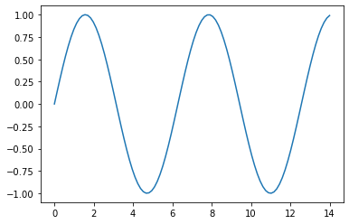

```python
# 그래프 그리기
plt.plot(x,y)
```

```python
n = np.array([1,2,3,4,5])
print(type(n))
n
```

```
<class 'numpy.ndarray'>
```

```
array([1, 2, 3, 4, 5])
```

- 2005년 Travis Oliphant가 발표한 수치해석용 패키지
- ndarray는 Numpy의 핵심인 다차원 행렬 자료구조 클래스이다.
- 파이썬이 제공하는 List자료형과 동일한 출력 형태를 갖는다.
- Numpy의 행렬 연산은 C로 구현된 반복문 사용으로 Python반복문에 비해 속도가 빠르다

### Python의 리스트와 Numpy ndarray의 비고

- Python List
  - 여러가지 타입의 원소
  - linked List 구현한 구조
  - 메모리 용량이 크고 속도가 느림
  - 벡터와 연산 불가
- Numpy ndarray
  - 동일 타입의 원소
  - contiguous memory layout
    - (연속적인 메모리 배치(같은 타입) - 속도 향상
  - 메모리 최적화, 속도 향상
  - 벡터와 연산 가능

```python
a = [1,2,3]
a*2
```

```
[1, 2, 3, 1, 2, 3]
```

```python
## 벡터 연산 예
a = np.array([1,2,3])
a * 2
```

```
array([2, 4, 6])
```

### python 리스트와 numpy의 처리 시간 비교

```python
a = np.arange(1000000)
%time a2 = a**2
```

```
CPU times: total: 0 ns
Wall time: 0 ns
```

```python
L = range(1000000)
%time L2 = [i**2 for i in L]
```

```
CPU times: total: 219 ms
Wall time: 215 ms
```

```python
### 다차원 생성하기
a1 = [1,2,3]
a2 = [ [11,12,13],
       [21,22,23],
       [31,32,33]]
a2
```

```
[[11, 12, 13], [21, 22, 23], [31, 32, 33]]
```

```python
b1 = np.array([1,2,3])
b2 = np.array([ [11,12,13],
                [21,22,23],
                [31,32,33]])
b2
```

```
array([[11, 12, 13],
       [21, 22, 23],
       [31, 32, 33]])
```

```python
print("행렬의 차원 : ", b1.ndim, b2.ndim)
print("행렬의 크기 : ", b1.shape, b2.shape)
```

```
행렬의 차원 :  1 2
행렬의 크기 :  (3,) (3, 3)
```

### 데이터 접근

```python
a2[0]
```

```
[11, 12, 13]
```

```python
a2[0][1]
```

```
12
```

```python
print(b2[0])
print(b2[0][1])
print(b2[0,1])
```

```
[11 12 13]
12
12
```

```python
### 전체 데이터 중의 짝수만 뽑기
b2[ b2 % 2 ==0]
```

```
array([12, 22, 32])
```

### 03. matplotlib의 이해

목차로 이동하기

- 여러개의 그래프 그려보기
  - plt.subplot()의 이해
- 이미지 정보 표시 - imshow() 이해
- 이미지 저장 - savefig() 이해
- set_axis_off() 이해

```python
# x의 값을 이용하여 y값 (sin) 구하기
x = np.linspace(0,14,100)
y = np.sin(x)
```

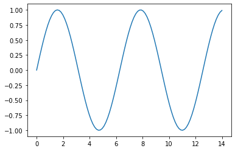

```python
# 그래프 그리기
plt.plot(x,y)
```

### 그래프의 범례 표시

```python
y1 = np.sin(x)
y2 = np.sin(x) * 2
y3 = np.sin(x) * 4
```

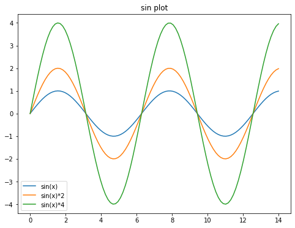

```python
plt.figure(figsize=(8,6))
plt.plot(x, y1, label="sin(x)")
plt.plot(x, y2, label="sin(x)*2")
plt.plot(x, y3, label="sin(x)*4")
plt.legend()
plt.title("sin plot")
```

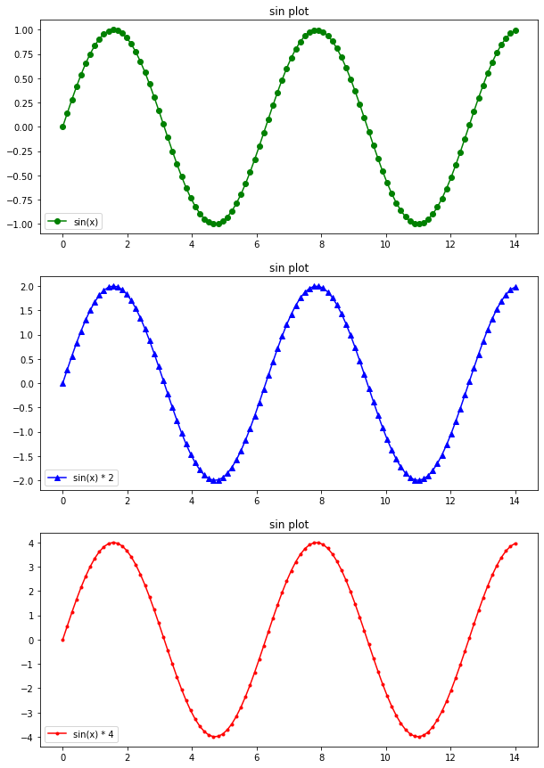

```python
plt.figure(figsize=(10,15))
plt.subplot(3, 1, 1)
plt.title("sin plot")
plt.plot(x, y1, 'go-', label='sin(x)')

plt.legend()
plt.subplot(3, 1, 2)
plt.title("sin plot")
plt.plot(x, y2, 'b^-', label='sin(x) * 2')

plt.legend()
plt.subplot(3, 1, 3)
plt.title("sin plot")
plt.plot(x, y3, 'r.-', label='sin(x) * 4')

plt.legend()
plt.show()
```

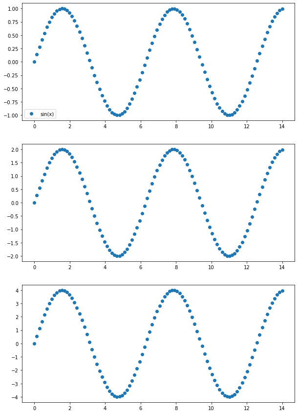

```python
fig, ax = plt.subplots(3, 1, figsize=(10,15))

ax[0].plot(x, y1, 'o', label='sin(x)')
ax[0].legend()
ax[1].plot(x, y2, 'o', label='sin(x)')
ax[2].plot(x, y3, 'o', label='sin(x)')
plt.show()
```

### 04. 이미지 시각화 - imshow의 이해

목차로 이동하기

```python
import urllib.request

url = "https://pythonstart.github.io/web/dog01.jpg"
savename = 'dog.jpg'

urllib.request.urlretrieve(url,savename)
print("저장완료")
```

```
저장완료
```

```python
!dir dog*
```

```
 D 드라이브의 볼륨: wjv_backup
 볼륨 일련 번호: D856-9720

 D:\Github\DeepLearning_Basic_Class 디렉터리

2022-11-16  오후 06:09         6,847,926 dog.jpg
               1개 파일           6,847,926 바이트
               0개 디렉터리   8,123,031,552 바이트 남음
```

```
[[[117 123 119]
  [118 124 120]
  [118 124 120]
  ...
  [116 113 108]
  [118 113 109]
  [117 112 108]]

 [[117 123 119]
  [118 124 120]
  [119 125 121]
  ...
  [117 114 109]
  [117 114 109]
  [117 114 109]]

 [[117 122 118]
  [118 123 119]
  [118 124 120]
  ...
  [116 113 108]
  [115 112 107]
  [116 113 108]]

 ...

 [[186 186 188]
  [186 186 188]
  [187 187 189]
  ...
  [ 83  80  75]
  [ 82  79  74]
  [ 80  77  72]]

 [[184 184 184]
  [184 184 184]
  [186 186 186]
  ...
  [ 81  78  73]
  [ 81  78  73]
  [ 80  77  72]]

 [[181 181 179]
  [181 181 179]
  [184 184 182]
  ...
  [ 80  77  70]
  [ 81  78  71]
  [ 79  76  69]]]
```

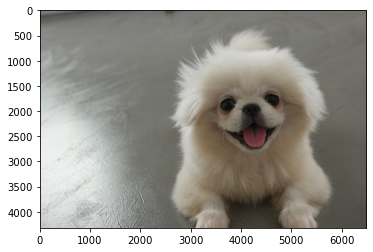

```python
fig, ax = plt.subplots()
image = plt.imread("dog.jpg") # 이미지 읽기
print(image)
ax.imshow(image)
```

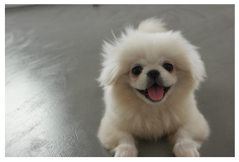

```python
### set_axis_off() 이해 - 축을 없애기
### savefig() 이해 - 파일로 저장
fig, ax = plt.subplots()
ax.set_axis_off()
ax.imshow(image)
fig.savefig('Plot_without_axes.png')
```

```python
!dir Plot_*
```

```
 D 드라이브의 볼륨: wjv_backup
 볼륨 일련 번호: D856-9720

 D:\Github\DeepLearning_Basic_Class 디렉터리

2022-11-16  오후 06:09           109,365 Plot_without_axes.png
               1개 파일             109,365 바이트
               0개 디렉터리   8,123,031,552 바이트 남음
```

### 05. seaborn에 대해 알아보기

목차로 이동하기

```python
import seaborn as sns
import pandas as pd
```

```python
tips = sns.load_dataset("tips") ## tips의 데이터 셋 불러오기
tips.head() ## 앞의 데이터만 살펴보기 tips.tail() - 뒤의 데이터 셋
```

|  | total_bill | tip | sex | smoker | day | time | size |
| --- | --- | --- | --- | --- | --- | --- | --- |
| 0 | 16.99 | 1.01 | Female | No | Sun | Dinner | 2 |
| 1 | 10.34 | 1.66 | Male | No | Sun | Dinner | 3 |
| 2 | 21.01 | 3.50 | Male | No | Sun | Dinner | 3 |
| 3 | 23.68 | 3.31 | Male | No | Sun | Dinner | 2 |
| 4 | 24.59 | 3.61 | Female | No | Sun | Dinner | 4 |

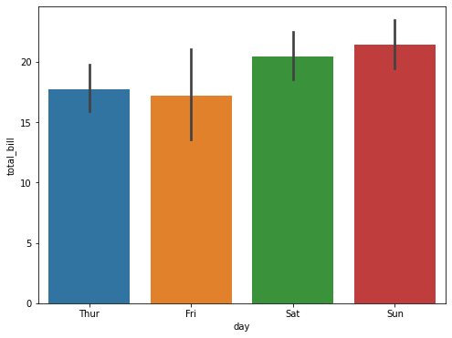

```python
### 요일별 식사 금액은 얼마나 될까?
plt.figure(figsize=(8,6))
sns.barplot(x="day", y="total_bill", data=tips)
plt.show()
```

### (실습) 요일별 Tips은 얼마나 될까?

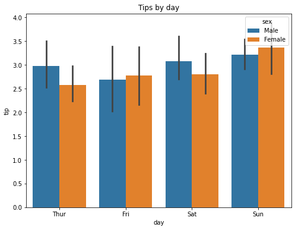

```python
# 요일별 tip은 남성과 여성은 어떠할까?
plt.figure(figsize=(8,6))
sns.barplot(x="day", y="tip", hue="sex", data=tips) # hue를 이용하여 구분.
plt.title("Tips by day")
plt.show()
```

### 06. pandas 기본

목차로 이동하기

- 리스트, 딕셔너리 간단히 만들어보기
- Pandas 불러오기
- 행과 열 확인 shape
- 컬럼명 확인 columns
- 정보 확인 info()
- 요약값 확인 describe()
- 몇행만 확인하기 head(), tail()
- Series 자료형, DataFrame 자료형 만들기
- 원하는 열 선택(하나)
- 원하는 열 선택(여러개)
- 원하는 행 선택(하나)
- 원하는 행 선택(여러개)
- 새로운 컬럼 생성

### 데이터 준비 및 csv 및 excel 파일 생성

```python
iris = sns.load_dataset("iris")
iris.head()
```

|  | sepal_length | sepal_width | petal_length | petal_width | species |
| --- | --- | --- | --- | --- | --- |
| 0 | 5.1 | 3.5 | 1.4 | 0.2 | setosa |
| 1 | 4.9 | 3.0 | 1.4 | 0.2 | setosa |
| 2 | 4.7 | 3.2 | 1.3 | 0.2 | setosa |
| 3 | 4.6 | 3.1 | 1.5 | 0.2 | setosa |
| 4 | 5.0 | 3.6 | 1.4 | 0.2 | setosa |

```python
## csv 데이터 셋, excel 데이터 셋 만들기
iris.to_csv("iris.csv", index=False)
iris.to_excel("iris.xlsx", index=False)
```

```python
!dir iris*
```

```
 D 드라이브의 볼륨: wjv_backup
 볼륨 일련 번호: D856-9720

 D:\Github\DeepLearning_Basic_Class 디렉터리

2022-11-16  오후 06:09             4,009 iris.csv
2022-11-16  오후 06:09             8,750 iris.xlsx
               2개 파일              12,759 바이트
               0개 디렉터리   8,123,031,552 바이트 남음
```

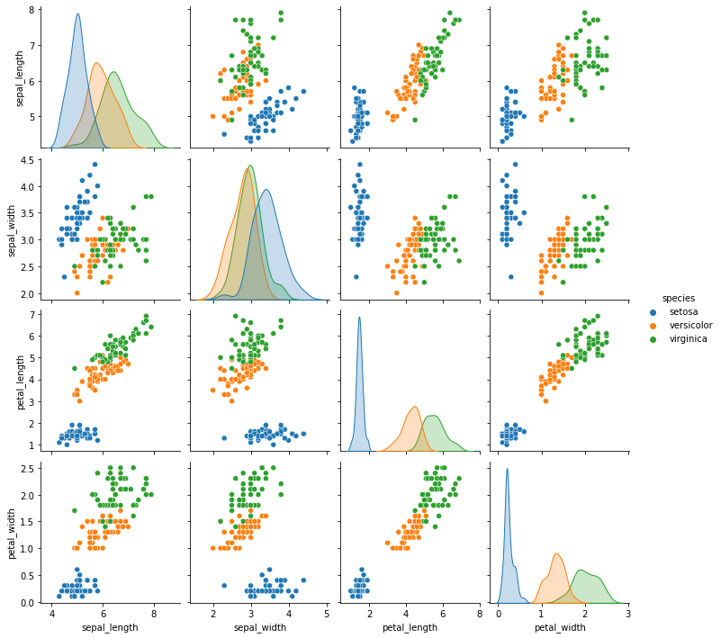

```python
## 산점도 그래프 확인
sns.pairplot(iris, hue="species")
```

```python
# 리스트
myfood = ['banana', 'apple', 'candy']
print(myfood[0])
print(myfood[1])
print(myfood[2])
print(myfood[1:3])
```

```
banana
apple
candy
['apple', 'candy']
```

```python
for item in myfood:
 print(item)
```

```
banana
apple
candy
```

```python
# 딕셔너리
dict1 = {'one':'하나', 'two':"둘", 'three':'셋'}
dict2 = {1:"하나", 2:"둘", 3:"셋"}
dict3 = {'col1':[1,2,3], 'col2':['a','b','c']}

print(dict1)
print(dict2)
print(dict3)
```

```
{'one': '하나', 'two': '둘', 'three': '셋'}
{1: '하나', 2: '둘', 3: '셋'}
{'col1': [1, 2, 3], 'col2': ['a', 'b', 'c']}
```

```python
print(dict1['one'])
print(dict2[2])
print(dict3['col2'])
```

```
하나
둘
['a', 'b', 'c']
```

```python
dat = pd.read_csv("iris.csv")
dat.shape # 데이터의 행열 (크기)
```

```
(150, 5)
```

```python
dat.head() ## 앞의 데이터 보기
```

|  | sepal_length | sepal_width | petal_length | petal_width | species |
| --- | --- | --- | --- | --- | --- |
| 0 | 5.1 | 3.5 | 1.4 | 0.2 | setosa |
| 1 | 4.9 | 3.0 | 1.4 | 0.2 | setosa |
| 2 | 4.7 | 3.2 | 1.3 | 0.2 | setosa |
| 3 | 4.6 | 3.1 | 1.5 | 0.2 | setosa |
| 4 | 5.0 | 3.6 | 1.4 | 0.2 | setosa |

```python
dat.tail() ## 뒤의 데이터 보기
```

|  | sepal_length | sepal_width | petal_length | petal_width | species |
| --- | --- | --- | --- | --- | --- |
| 145 | 6.7 | 3.0 | 5.2 | 2.3 | virginica |
| 146 | 6.3 | 2.5 | 5.0 | 1.9 | virginica |
| 147 | 6.5 | 3.0 | 5.2 | 2.0 | virginica |
| 148 | 6.2 | 3.4 | 5.4 | 2.3 | virginica |
| 149 | 5.9 | 3.0 | 5.1 | 1.8 | virginica |

```python
dat.columns ## 데이터의 컬럼보기
```

```
Index(['sepal_length', 'sepal_width', 'petal_length', 'petal_width',
       'species'],
      dtype='object')
```

```python
dat.describe() ## 데이터의 요약값 보기
```

|  | sepal_length | sepal_width | petal_length | petal_width |
| --- | --- | --- | --- | --- |
| count | 150.000000 | 150.000000 | 150.000000 | 150.000000 |
| mean | 5.843333 | 3.057333 | 3.758000 | 1.199333 |
| std | 0.828066 | 0.435866 | 1.765298 | 0.762238 |
| min | 4.300000 | 2.000000 | 1.000000 | 0.100000 |
| 25% | 5.100000 | 2.800000 | 1.600000 | 0.300000 |
| 50% | 5.800000 | 3.000000 | 4.350000 | 1.300000 |
| 75% | 6.400000 | 3.300000 | 5.100000 | 1.800000 |
| max | 7.900000 | 4.400000 | 6.900000 | 2.500000 |

```python
dat.info() # 데이터의 자료형 요약 보기
```

```
<class 'pandas.core.frame.DataFrame'>
RangeIndex: 150 entries, 0 to 149
Data columns (total 5 columns):
 #   Column        Non-Null Count  Dtype
---  ------        --------------  -----
 0   sepal_length  150 non-null    float64
 1   sepal_width   150 non-null    float64
 2   petal_length  150 non-null    float64
 3   petal_width   150 non-null    float64
 4   species       150 non-null    object
dtypes: float64(4), object(1)
memory usage: 6.0+ KB
```

```python
dat.isnull().sum() # 데이터의 결측치 보기
```

```
sepal_length    0
sepal_width     0
petal_length    0
petal_width     0
species         0
dtype: int64
```